# Domestic violence experienced by women in Egypt

Egypt Demographic and Health Survey 2014

Anastasiia Mikhailova

2024-03-31

# Introduction

According to the [European comission](https://commission.europa.eu/strategy-and-policy/policies/justice-and-fundamental-rights/gender-equality/gender-based-violence/what-gender-based-violence_en), **Gender-based violence (GBV)** is violence directed against a person because of that person’s gender or violence that affects persons of a particular gender disproportionately. Both men and women are suffering from GBV, however, women and girls are much more likely to experience it. [World Bank](https://www.worldbank.org/en/topic/socialsustainability/brief/violence-against-women-and-girls) calls it a global pandemic, since it affects 1 in 3 women in their lifetime and is among most common violations of human rights.

GBV is an umbrella term that includes physical, sexual and psychological violence. Victims of such violence can experience detrimental psychological and reproductive health consequences, including forced and unwanted pregnancies, unsafe abortions, depression and self-harm among other risks. Worldwide, GBV against women and girls is among most common violations of human rights.

The aim of this report is to analyse the data on domestic violence from DHS survey conducted in 2014 in Egypt. Domestic violence or [Intimate Partner Violence (IPV)](https://www.rescue.org/article/what-gender-based-violence-and-how-do-we-prevent-it), even though can be distinguished from GBV depending on how the topic is framed, is the most common form of violence against women and girls.

## DHS data used in this report

The set of questions related to the domestic violence is in the optional module of questions, thus, not all the participants were asked these questions.

Key points:

- A total of 6,693 women were selected for inclusion in the Domestic Violence module
- From each household in the subsample, only one woman was chosen
- The criteria for selection included women who are either currently married, widowed or divorced
- The domestic violence module can be entirely skipped if, despite all the interviewer’s efforts, complete privacy for the duration of the module is not possible

The DHS-8 survey (2021) also covers never-married women, examining incidents of violence by any perpetrator. However, the survey used in this report was carried out in 2014 and includes variables related to violence inflicted only by a husband or partner. The term “partner” is [defined](https://dhsprogram.com/data/Guide-to-DHS-Statistics/) as a person with whom woman lives with as if married.

## Selected Variables

Variables selected for analysis are falling under three categories:

- Physical violence: ever been pushed, shook or had something thrown (**d105a**), slapped (**d105b**), punched with fist or hit by something harmful (**d105c**), kicked or dragged (**d105d**), strangled or burnt (**d105e**), attacked with a knife, gun or other weapon (**d105f**), had arm twisted or hair pulled (**d105j**) by husband/partner
- Sexual violence: ever been physically forced into unwanted sex (**d105h**) or other unwanted sexual act (**d105i**), ever been physically forced to perform sexual act (**d105k**)
- Emotional violence: ever been humiliated (**d103a**), threatened with harm (**d103b**), insulted or made to feel bad (**d103c**) by husband/partner

These variables were combined into 4 different types/levels of violence:

- Experienced any emotional violence (d103a-d103c) - **d104**
- Experienced any less severe violence (d105a-c,j) - **d106**
- Experienced any severe violence (d105d-f) - **d107**
- Experienced any sexual violence (d105h-i,k) - **d108**

Additionally, demographic data was included (age, region, number of children, etc.)

# Data Visualization

## Segmentation analysis: spousal violence exposure

Analyzing various factors related to physical, sexual, or emotional violence, it was found that 1,939 women, nearly **one-third of the sample**, had experienced at least one form of violence from their husband or partner.

The data was divided based on whether the women experienced violence or not. The subsequent analysis (see the table below), revealed certain trends. While conclusions are tentative without deeper statistical evaluation, the data suggests that women with higher education levels were less likely to face partner violence. Similarly, women in the wealthiest category also appeared less vulnerable to such violence. Conversely, women living in rural areas, particularly in Upper Egypt’s rural regions, were more prone to experiencing violence. A higher number of children correlated with a small increase in the likelihood of domestic violence.

|  | Did not experience violence | Experienced violence |
| --- | --- | --- |
| n | 4753 | 1939 |
| age (mean (SD)) | 33.15 (8.43) | 32.93 (8.09) |
| highest education (%) |  |  |
| no education | 935 (19.7) | 502 (25.9) |
| primary | 401 ( 8.4) | 246 (12.7) |
| secondary | 2570 (54.1) | 1019 (52.6) |
| higher | 847 (17.8) | 172 ( 8.9) |
| wealth index (%) |  |  |
| poorest | 716 (15.1) | 385 (19.9) |
| poorer | 857 (18.0) | 377 (19.4) |

[output cut: 14 more lines]

## Acts of physical, emotional and sexual violence

The most common forms of violence reported in the data were slaps, pushes, and insults from a partner (Fig.1). The data shows a higher incidence of less severe physical and emotional violence. In contrast, severe physical acts and sexual violence were less common, affecting about 1 to 4% of the entire sample.

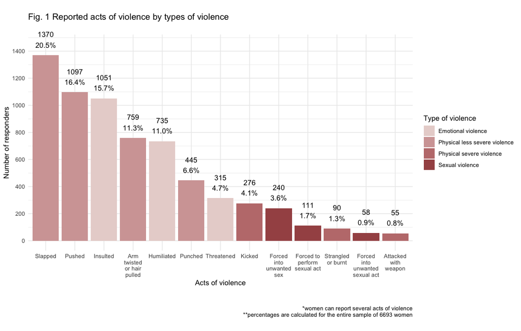

To analyze the likelihood of experiencing only a single act of violence, a similar chart was developed (Fig.2). In this data subset women were more likely to report just one act of violence if it was among the more common types, such as slaps or insults. However, the women reporting only one kind of act was a fraction of total, with majority reporting more than one. Less frequent and thus more severe acts of violence for several categories occurred only in conjunction with at least one other form of violence from the categories presented.

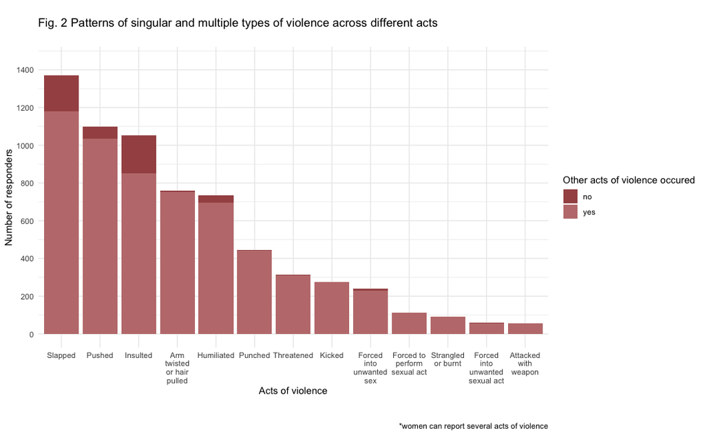

## Detalization of the most and least prevalent acts of violence

The acts of violence happening more frequently (often and sometimes) within the given population were insults and forced unwanted sex. Despite minimal differences in frequency between the most and least common acts and small number of responds in the least prevalent acts, a notable pattern emerges: more than half of women reported experiencing these acts repeatedly and within the last 12 months. It also indicates that women subjected to severe physical or sexual violence are suffering it repeatedly (disproving the assumption that less severe acts would be less frequent and recent).

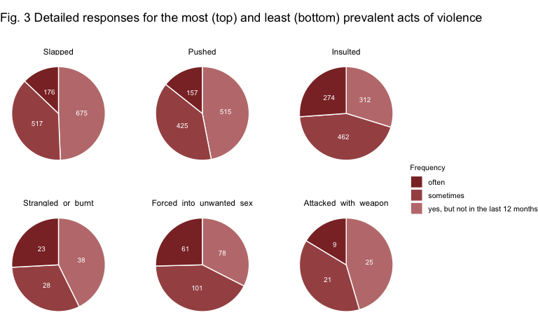

*Note: Responses ‘yes, but frequency in last 12 months missing’ were excluded due to low prevalence (3 responses in the category ‘Insulted’, 2 in ‘Slapped’ and 1 in ‘Strangled or burnt’).*

## Types of violence by levels of education and wealth

In the analysis of the proportion of specific types of violence by wealth and education level (Fig.4), the data reveals a trend of emotional violence growing alongside both wealth and educational levels. Proportion of emotional violence is the highest among women with higher levels of education.

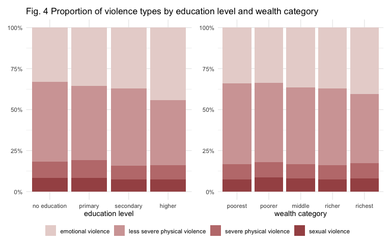

# Conclusions

A third of the women in this data sample have experienced domestic violence from their partners, a notably high figure. The most common types of violence reported are emotional or less severe physical acts. However, the incidence of the most severe forms of violence is significant, with these acts occurring repeatedly and within the last 12 months for over half of the respondents.

# Limitations

The analysis did not take into account the statistical weights, and a thorough statistical evaluation was not conducted. Therefore, the conclusions and assumptions drawn may be somewhat inaccurate.